# EDA

2024-09-21

# Load the data

```r
current_folder <- getwd()
clean_data <- read.csv(file.path(current_folder, "data/clean_data.csv"))

head(clean_data)
```

```
##   AdjustedYear     ID Sex    Team Age Weight Height NOC Season      Sport
## 1         1896 135285   M  Greece  NA     NA     NA GRE Summer  Athletics
## 2         1896  39654   M  Greece  NA     NA     NA GRE Summer  Athletics
## 3         1896  35094   M  Greece  NA     NA     NA GRE Summer  Athletics
## 4         1896 129362   M Hungary  23     NA     NA HUN Summer Gymnastics
## 5         1896  56757   M Hungary  NA     NA     NA HUN Summer Gymnastics
## 6         1896  93996   M  Greece  NA     NA     NA GRE Summer   Shooting
##                                       Event Medal AthleteCountry
## 1               Athletics Men's Triple Jump  <NA>         Greece
## 2                  Athletics Men's Marathon  <NA>         Greece
## 3              Athletics Men's 1,500 metres  <NA>         Greece
## 4           Gymnastics Men's Horizontal Bar  <NA>        Hungary
## 5            Gymnastics Men's Parallel Bars  <NA>        Hungary
## 6 Shooting Men's Military Rifle, 200 metres  <NA>         Greece
##   WeightHeightRation Country Year HomeAway
## 1                 NA  Greece 1896     Home
## 2                 NA  Greece 1896     Home
## 3                 NA  Greece 1896     Home
## 4                 NA  Greece 1896     Away
## 5                 NA  Greece 1896     Away
## 6                 NA  Greece 1896     Home
```

## EDA

We have data from 1896 to 2016:

```r
# YEAR -----------------------------------------------
c(min(clean_data$AdjustedYear), max(clean_data$AdjustedYear))
```

```
## [1] 1896 2016
```

The fist summer Summer Olympics (1896) included 9 sports, the last (2016) ones include 34. The fist summer Winter Olympics (1924) included 10 sports, the last (2014) ones include 15.

# Sport

Q1: How many sports in each season? And how the #sports per season changed with time?

```r
clean_data %>%
  group_by(Season,Year) %>% summarise(n_distinct(Sport), .groups='drop') %>%
  group_by(Season) %>%
  filter(Year==max(Year) | Year==min(Year))
```

```
## # A tibble: 4 × 3
## # Groups:   Season [2]
##   Season  Year `n_distinct(Sport)`
##   <chr>  <int>               <int>
## 1 Summer  1896                   9
## 2 Summer  2016                  34
## 3 Winter  1924                  10
## 4 Winter  2014                  15
```

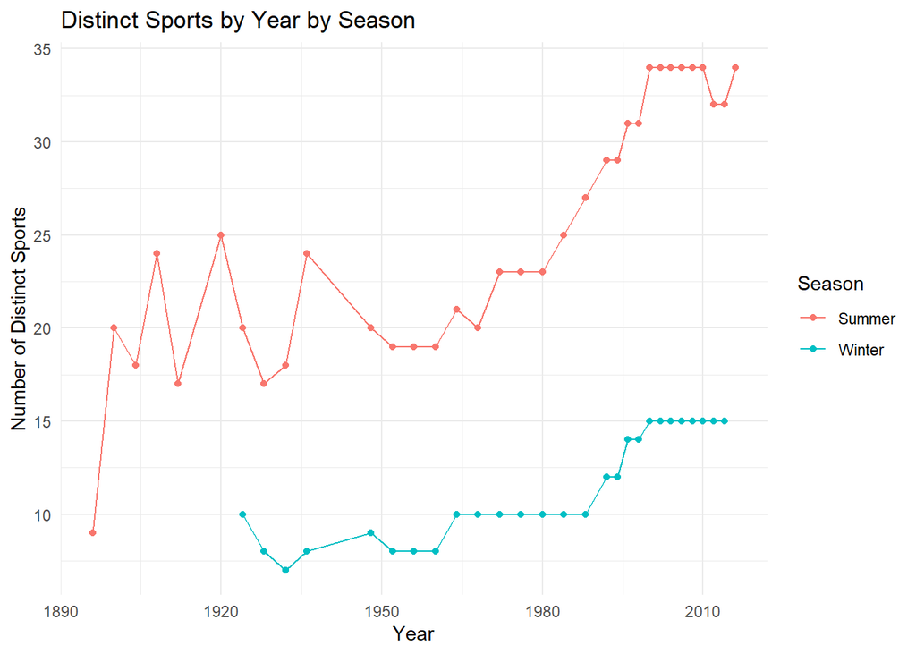

```r
clean_data %>%
  group_by(Year, Season) %>%
  summarize(NSports = n_distinct(Sport), .groups='drop') %>%
  ggplot(aes(x = Year, y = NSports, color=Season)) +
  geom_line() +
  geom_point() +
  labs(title = "Distinct Sports by Year by Season",
       x = "Year",
       y = "Number of Distinct Sports") +
  theme_minimal()
```

Q2: Which sports have been in the Olympic games every single year?

```r
clean_data %>%
  group_by(Sport) %>%
  summarise(Years_Present = n_distinct(AdjustedYear)) %>%
  filter(Years_Present == n_distinct(clean_data$AdjustedYear)) %>%
  pull(Sport)
```

```
## [1] "Athletics"  "Cycling"    "Fencing"    "Gymnastics" "Swimming"
```

Q3: Which sports have been played just once in the Olympics?

```r
clean_data %>%
  group_by(Sport) %>%
  summarize(YearCount = n_distinct(Year),
            YearPlayed = first(Year[which(n_distinct(Year) == 1)])) %>%
  filter(YearCount == 1)
```

```
## # A tibble: 10 × 3
##    Sport               YearCount YearPlayed
##    <chr>                   <int>      <int>
##  1 Aeronautics                 1       1936
##  2 Basque Pelota               1       1900
##  3 Cricket                     1       1900
##  4 Croquet                     1       1900
##  5 Jeu De Paume                1       1908
##  6 Military Ski Patrol         1       1924
##  7 Motorboating                1       1908
##  8 Racquets                    1       1908
##  9 Roque                       1       1904
## 10 Rugby Sevens                1       2016
```

## Height and Weight

Q1: Is there high correlation?

```r
cor(clean_data$Weight, clean_data$Height, use = "complete.obs")
```

```
## [1] 0.7974434
```

Q2: Is the height distribution of athletes different in different sports?

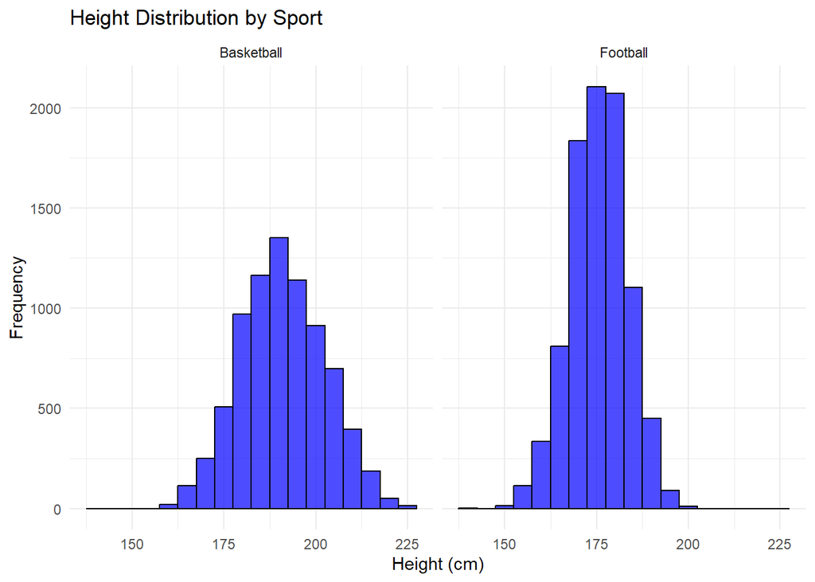

```r
clean_data %>%
  filter(Sport %in% c('Basketball','Football')) %>%
  ggplot(aes(x = Height)) +
  geom_histogram(binwidth = 5, fill = 'blue', color = 'black', alpha = 0.7) +
  facet_wrap(~ Sport) +
  theme_minimal() +
  labs(title = 'Height Distribution by Sport', x = 'Height (cm)', y = 'Frequency')
```

Q3: T test to check if Basketball players are taller than Football players

```r
basketball_players <- clean_data %>% filter(Sport == "Basketball")
football_players <- clean_data %>% filter(Sport == "Football")
t.test(basketball_players$Height, football_players$Height, alternate='greater')
```

```
##
##  Welch Two Sample t-test
##
## data:  basketball_players$Height and football_players$Height
## t = 100.11, df = 13449, p-value < 2.2e-16
## alternative hypothesis: true difference in means is not equal to 0
## 95 percent confidence interval:
##  15.08184 15.68424
## sample estimates:
## mean of x mean of y
##  190.8951  175.5120
```

Q4: ANOVA Test: Is the weight distribution of athletes different in different sports?

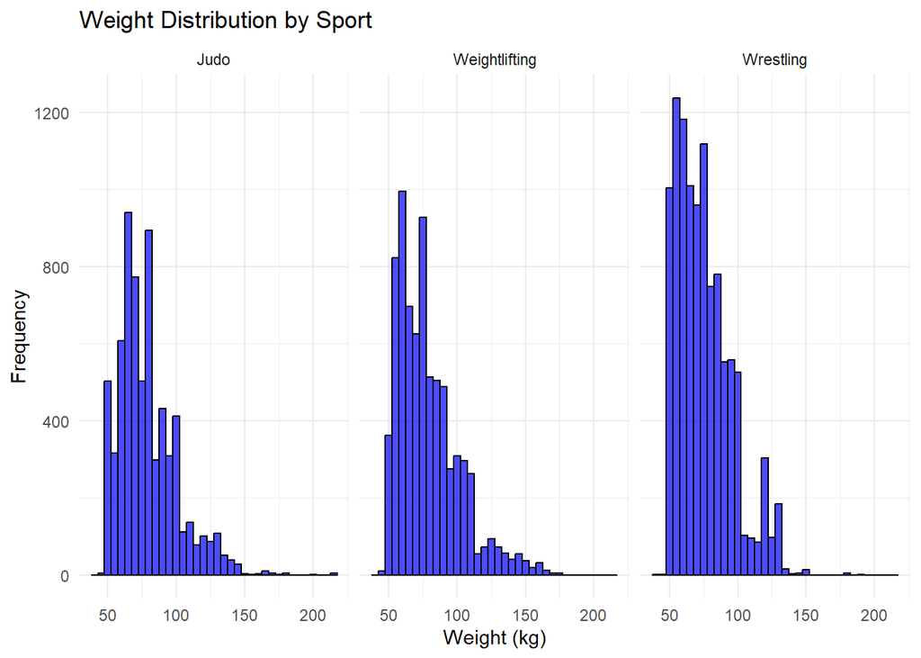

```r
clean_data %>%
  filter(Sport %in% c('Wrestling','Weightlifting','Judo')) %>%
  ggplot(aes(x = Weight)) +
  geom_histogram(binwidth = 5, fill = 'blue', color = 'black', alpha = 0.7) +
  facet_wrap(~ Sport) +
  theme_minimal() +
  labs(title = 'Weight Distribution by Sport', x = 'Weight (kg)', y = 'Frequency')
```

```r
weight_diffs <- clean_data %>%
  filter(Sport %in% c('Wrestling','Weightlifting','Judo'))
anova <- aov(Weight~Sport, data=weight_diffs)
summary(anova)
```

```
##                Df   Sum Sq Mean Sq F value Pr(>F)
## Sport           2    66746   33373   74.59 <2e-16 ***
## Residuals   24981 11176370     447
## ---
## Signif. codes:  0 '***' 0.001 '**' 0.01 '*' 0.05 '.' 0.1 ' ' 1
## 4419 observations deleted due to missingness
```

```r
TukeyHSD(anova, conf.level = 0.95)
```

```
##   Tukey multiple comparisons of means
##     95% family-wise confidence level
##
## Fit: aov(formula = Weight ~ Sport, data = weight_diffs)
##
## $Sport
##                                diff        lwr        upr     p adj
## Weightlifting-Judo       0.03225926 -0.7956476  0.8601661 0.9954122
## Wrestling-Judo          -3.29045709 -4.0623631 -2.5185511 0.0000000
## Wrestling-Weightlifting -3.32271634 -4.0669577 -2.5784750 0.0000000
```

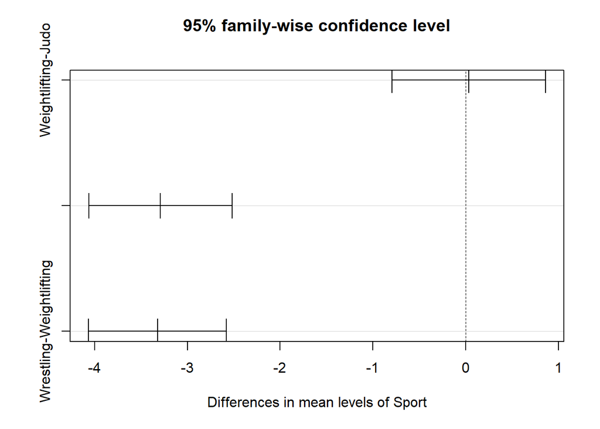

```r
plot(TukeyHSD(anova, conf.level = 0.95))
```

Q5: Has weight and height changed over time? Which sports have seen largest differences in weight over time?

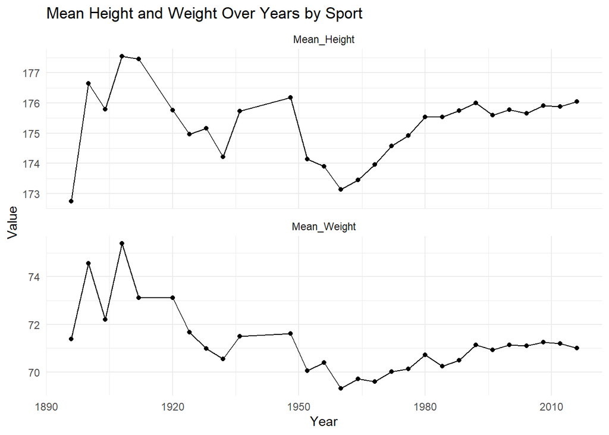

```r
clean_data %>%
  group_by(AdjustedYear) %>%
  summarise(
    Mean_Height = mean(Height, na.rm=T),
    Mean_Weight = mean(Weight, na.rm=T)
  ) %>%
  pivot_longer(cols = c(Mean_Height, Mean_Weight), names_to = "Metric", values_to = "Value") %>%
  ggplot(aes(x = AdjustedYear, y = Value)) +
  geom_line() +
  geom_point() +
  facet_wrap(~ Metric, scales = "free_y", ncol = 1) +
  theme_minimal() +
  labs(title = 'Mean Height and Weight Over Years by Sport', x = 'Year', y = 'Value')
```

```r
# Q5: Which sports have seen largest differences in weight over time?
clean_data %>%
  group_by(Sport) %>%
  summarise(
    Mean_Height = mean(Height, na.rm=T),
    SD_Height = sd(Height, na.rm=T),
    Mean_Weight = mean(Weight, na.rm=T),
    SD_Weight = sd(Weight, na.rm=T)
    ) %>%
  arrange(desc(SD_Height))
```

```
## # A tibble: 66 × 5
##    Sport          Mean_Height SD_Height Mean_Weight SD_Weight
##    <chr>                <dbl>     <dbl>       <dbl>     <dbl>
##  1 Basketball            191.     11.4         85.8      14.8
##  2 Judo                  174.     10.5         78.7      21.3
##  3 Volleyball            187.     10.4         78.9      11.7
##  4 Rugby Sevens          175.     10.2         78.9      14.6
##  5 Wrestling             172.     10.1         75.4      20.0
##  6 Figure Skating        168.     10.0         59.5      11.7
##  7 Taekwondo             176.      9.97        68.1      13.5
##  8 Weightlifting         168.      9.92        78.7      22.5
##  9 Rowing                184.      9.92        80.2      13.1
## 10 Swimming              179.      9.90        70.6      11.3
## # ℹ 56 more rows
```

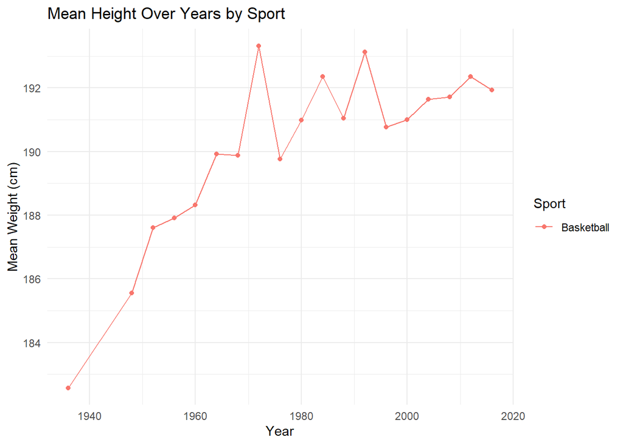

```r
# Basketball has seen larger changes in the height of the athletes over time
# Plot
clean_data %>%
  filter(Sport %in% c('Basketball')) %>%
  group_by(AdjustedYear,Sport) %>%
  summarise( Mean_Height = mean(Height, na.rm=T) ) %>%
  ggplot(aes(x = AdjustedYear, y = Mean_Height, color=Sport)) +
  geom_line() +
  geom_point() +
  theme_minimal() +
  labs(title = 'Mean Height Over Years by Sport', x = 'Year', y = 'Mean Weight (cm)')
```

Q6: Which sports have seen largest differences in weight over time?

```r
clean_data %>%
  group_by(Sport) %>%
  summarise(
    Mean_Weight = mean(Weight, na.rm=T),
    SD_Weight = sd(Weight, na.rm=T)
  ) %>%
  arrange(desc(SD_Weight))
```

```
## # A tibble: 66 × 3
##    Sport         Mean_Weight SD_Weight
##    <chr>               <dbl>     <dbl>
##  1 Weightlifting        78.7      22.5
##  2 Judo                 78.7      21.3
##  3 Wrestling            75.4      20.0
##  4 Athletics            69.2      15.4
##  5 Basketball           85.8      14.8
##  6 Rugby Sevens         78.9      14.6
##  7 Lacrosse             76.7      13.8
##  8 Taekwondo            68.1      13.5
##  9 Shooting             74.0      13.2
## 10 Handball             81.4      13.1
## # ℹ 56 more rows
```

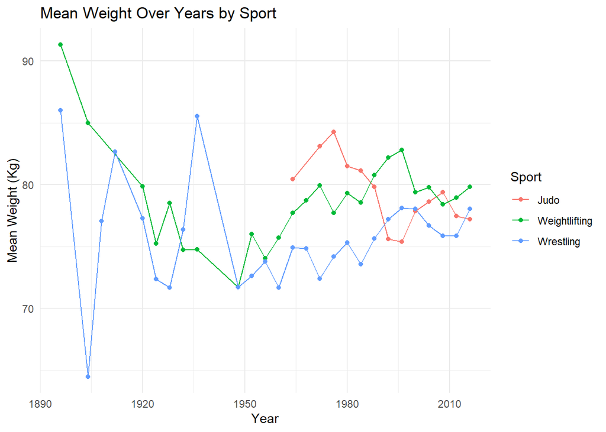

```r
# Weightlifting, Judo and Wrestling have seen larger changes in the weight of the athletes over time
# Plot
clean_data %>%
  filter(Sport %in% c('Weightlifting','Judo','Wrestling')) %>%
  group_by(AdjustedYear,Sport) %>%
  summarise( Mean_Weight = mean(Weight, na.rm=T) ) %>%
  ggplot(aes(x = AdjustedYear, y = Mean_Weight, color=Sport)) +
  geom_line() +
  geom_point() +
  theme_minimal() +
  labs(title = 'Mean Weight Over Years by Sport', x = 'Year', y = 'Mean Weight (Kg)')
```

## Country

Q1: Has country participation increased with time?

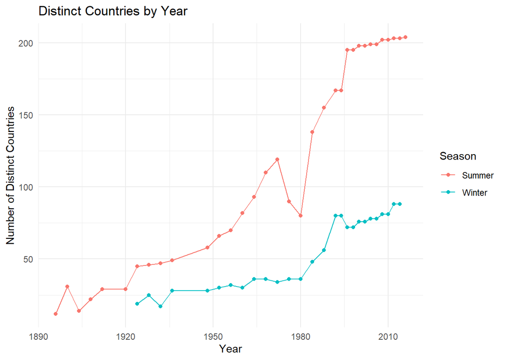

```r
clean_data %>%
  group_by(Year, Season) %>%
  summarize(NCountries = n_distinct(AthleteCountry), .groups='drop') %>%
  ggplot(aes(x = Year, y = NCountries, color=Season)) +
  geom_line() +
  geom_point() +
  labs(title = "Distinct Countries by Year",
       x = "Year",
       y = "Number of Distinct Countries") +
  theme_minimal()
```

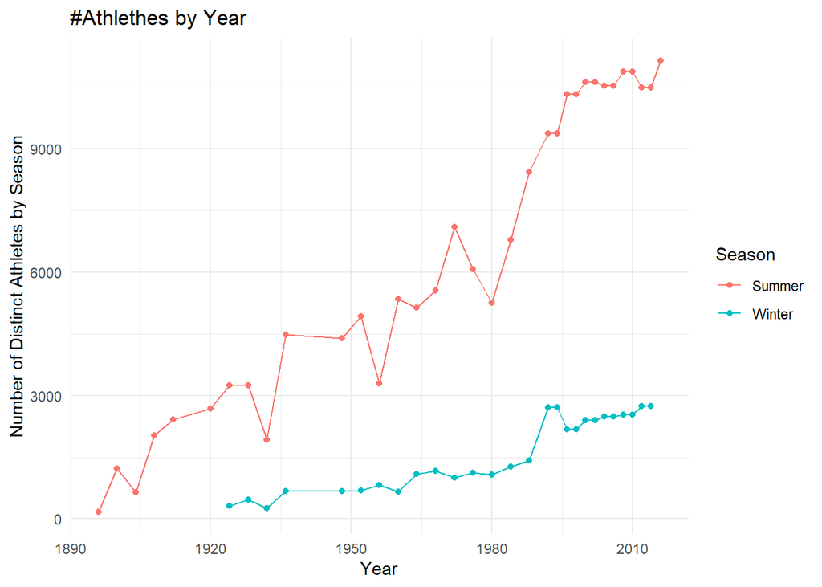

```r
clean_data %>%
  group_by(Year, Season) %>%
  summarize(NAthletes = n_distinct(ID), .groups='drop') %>%
  ggplot(aes(x = Year, y = NAthletes, color=Season)) +
  geom_line() +
  geom_point() +
  labs(title = "#Athlethes by Year",
       x = "Year",
       y = "Number of Distinct Athletes by Season") +
  theme_minimal()
```

Q2: Which sports offer the more medals (gold medals) on average?

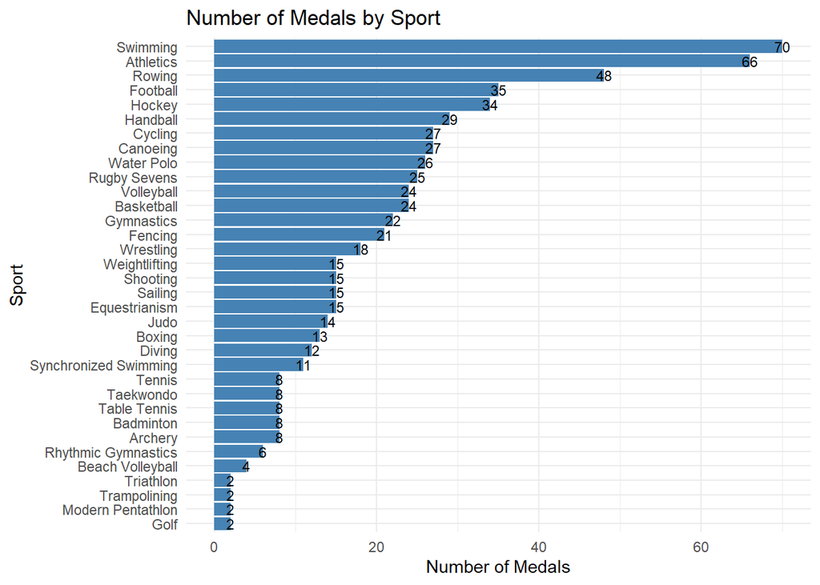

```r
clean_data %>%
  filter(Year == 2016) %>%
  group_by(Sport) %>% summarize(NMedals = sum(!is.na(Medal) & Medal=='Gold')) %>% arrange(desc(NMedals)) %>%
  ggplot(aes(x = reorder(Sport, NMedals), y = NMedals)) +
  geom_bar(stat = "identity", fill = "steelblue") +
  geom_text(aes(label = NMedals), size = 3, color = "black") +
  coord_flip() +
  labs(title = "Number of Medals by Sport",
       x = "Sport",
       y = "Number of Medals") +
  theme_minimal()
```

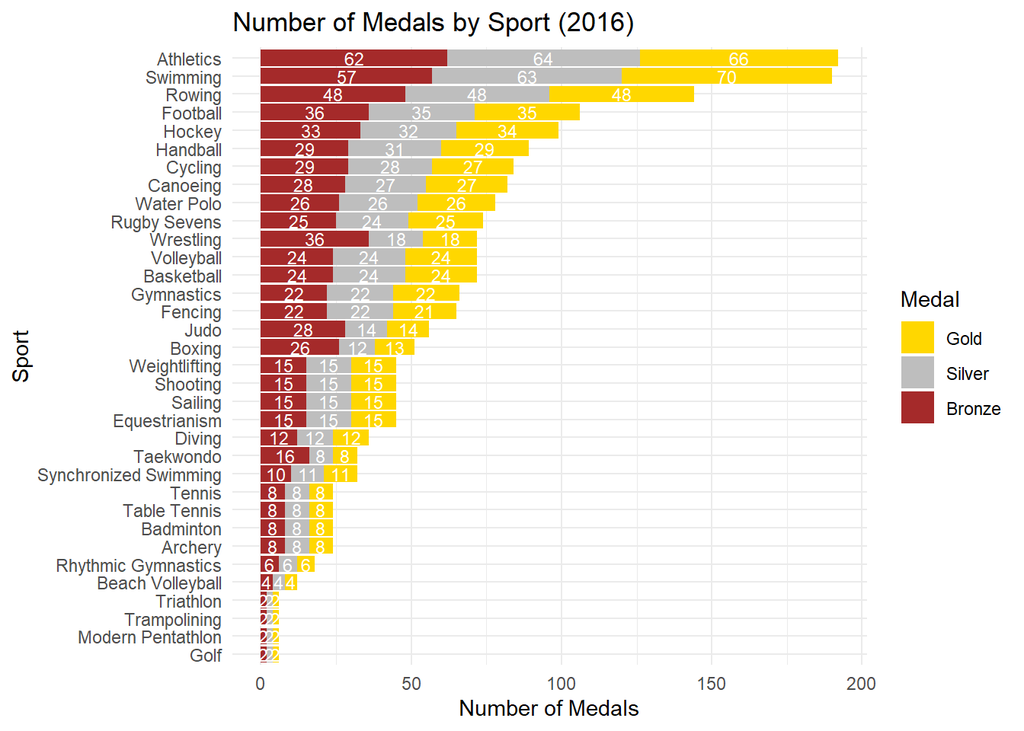

```r
clean_data %>%
  filter(Year == 2016 & !(is.na(Medal))) %>%
  group_by(Sport, Medal) %>%
  summarize(NMedals = sum(!is.na(Medal)), .groups = 'drop') %>%
  mutate(Medal = factor(Medal, levels = c("Gold", "Silver", "Bronze"))) %>%
  ggplot(aes(x = reorder(Sport, NMedals), y = NMedals, fill = Medal)) +
  geom_bar(stat = "identity") +
  geom_text(aes(label = NMedals), position = position_stack(vjust = 0.5), size = 3, color = "white") +
  coord_flip() +
  labs(title = "Number of Medals by Sport (2016)",
       x = "Sport",
       y = "Number of Medals") +
  scale_fill_manual(values = c("Gold" = "gold", "Silver" = "grey", "Bronze" = "brown")) +
  theme_minimal()
```

Why are there more gold medals than silver or bronze in some sports e.g. athletics?

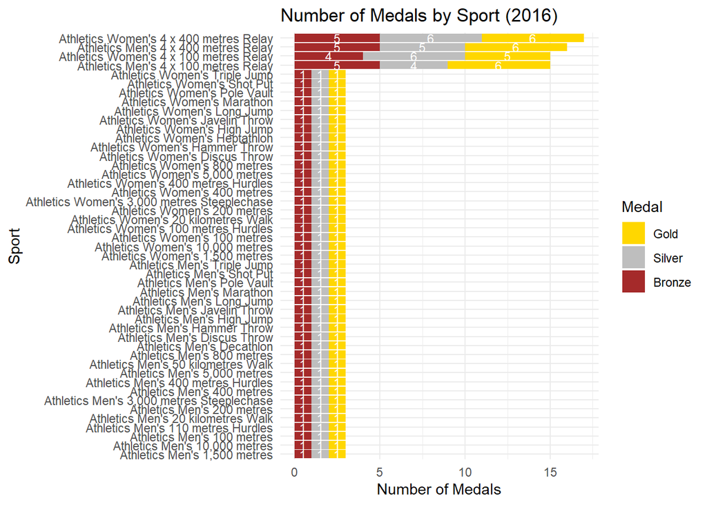

```r
clean_data %>%
  filter(Sport == 'Athletics' & Year == 2016 & !(is.na(Medal))) %>%
  group_by(Event, Medal) %>%
  summarize(NMedals = sum(!is.na(Medal)), .groups = 'drop') %>%
  mutate(Medal = factor(Medal, levels = c("Gold", "Silver", "Bronze"))) %>%
  ggplot(aes(x = reorder(Event, NMedals), y = NMedals, fill = Medal)) +
  geom_bar(stat = "identity") +
  geom_text(aes(label = NMedals), position = position_stack(vjust = 0.5), size = 3, color = "white") +
  coord_flip() +
  labs(title = "Number of Medals by Sport (2016)",
       x = "Sport",
       y = "Number of Medals") +
  scale_fill_manual(values = c("Gold" = "gold", "Silver" = "grey", "Bronze" = "brown")) +
  theme_minimal()
```

```r
clean_data %>%
  filter(Event == "Athletics Women's 4 x 400 metres Relay" & Year == 2016 & Medal == 'Gold')
```

```
##   AdjustedYear    ID Sex          Team Age Weight Height NOC Season     Sport
## 1         2016 34551   F United States  30     56    168 USA Summer Athletics
## 2         2016 32382   F United States  23     65    183 USA Summer Athletics
## 3         2016 36677   F United States  24     72    180 USA Summer Athletics
## 4         2016 77390   F United States  27     68    171 USA Summer Athletics
## 5         2016 88474   F United States  22     59    173 USA Summer Athletics
## 6         2016 46542   F United States  30     68    173 USA Summer Athletics
##                                    Event Medal AthleteCountry
## 1 Athletics Women's 4 x 400 metres Relay  Gold            USA
## 2 Athletics Women's 4 x 400 metres Relay  Gold            USA
## 3 Athletics Women's 4 x 400 metres Relay  Gold            USA
## 4 Athletics Women's 4 x 400 metres Relay  Gold            USA
## 5 Athletics Women's 4 x 400 metres Relay  Gold            USA
## 6 Athletics Women's 4 x 400 metres Relay  Gold            USA
##   WeightHeightRation Country Year HomeAway
## 1          0.3333333  Brazil 2016     Away
## 2          0.3551913  Brazil 2016     Away
## 3          0.4000000  Brazil 2016     Away
## 4          0.3976608  Brazil 2016     Away
## 5          0.3410405  Brazil 2016     Away
## 6          0.3930636  Brazil 2016     Away
```

# Olympics Host Advange

Is there a significant advantage for countries playing at home vs away?

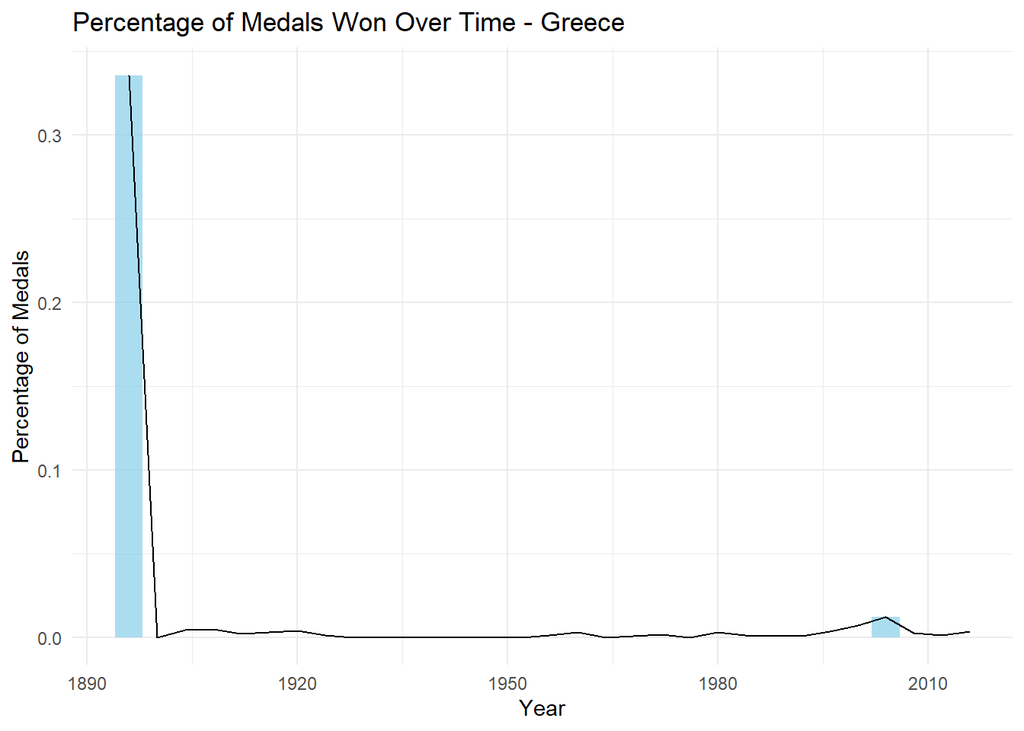

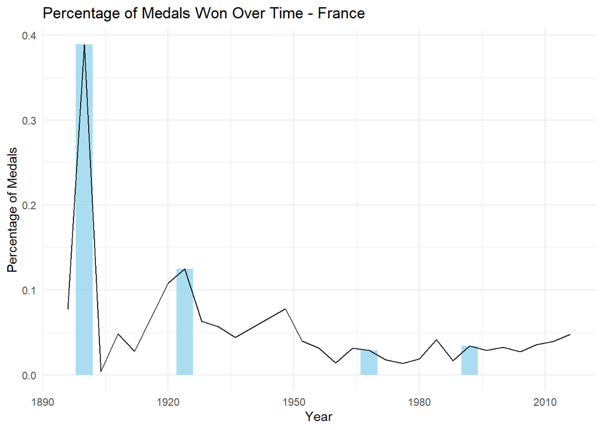

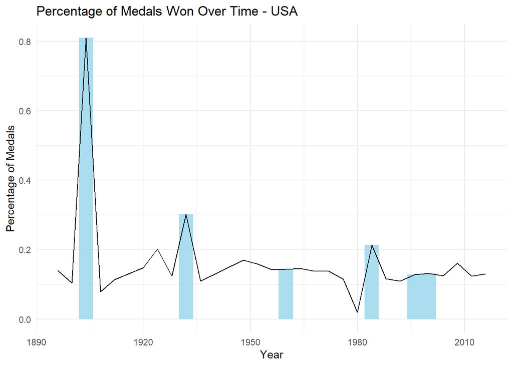

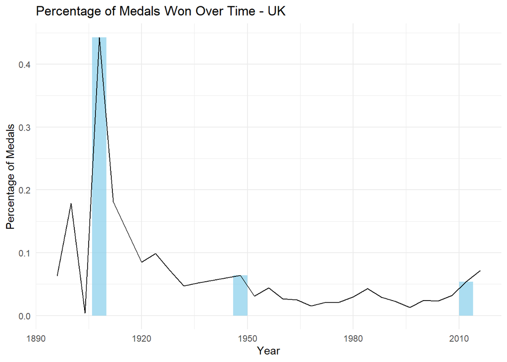

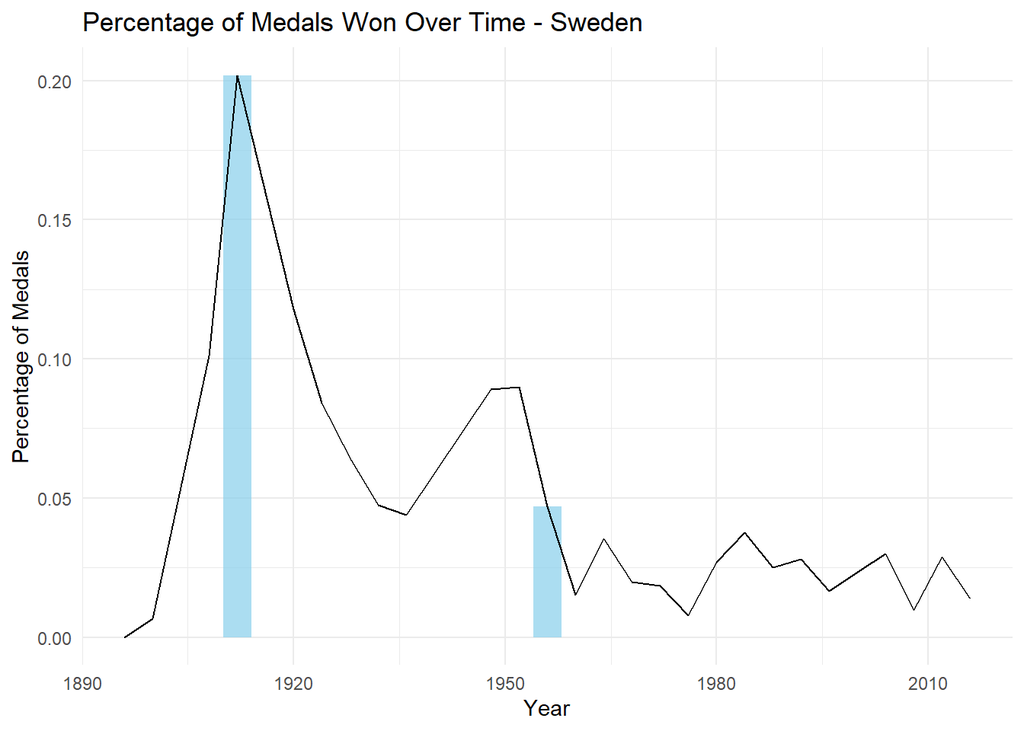

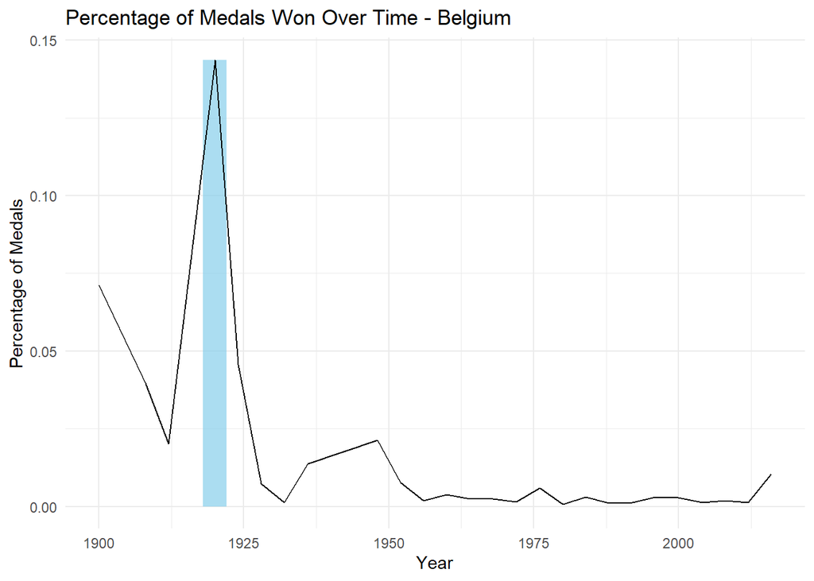

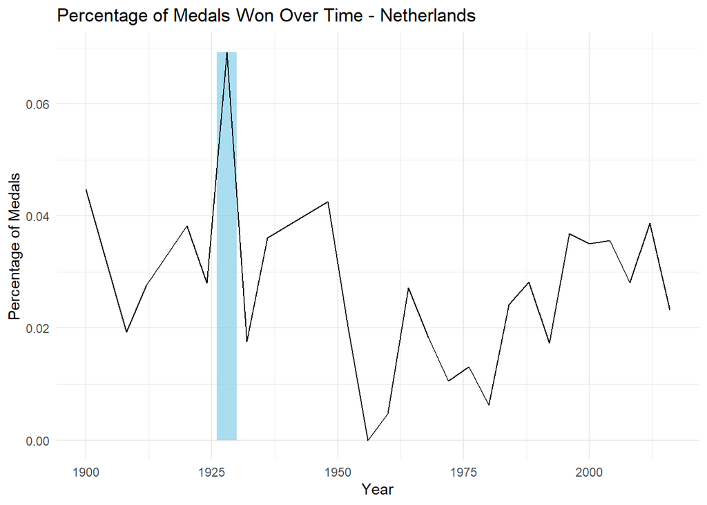

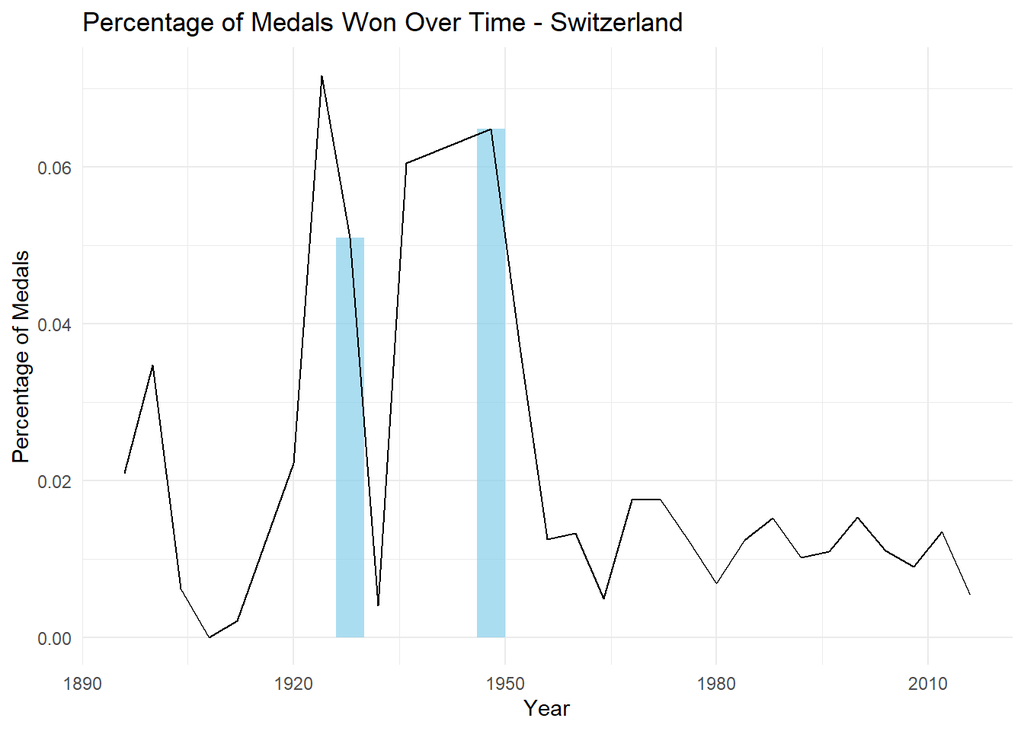

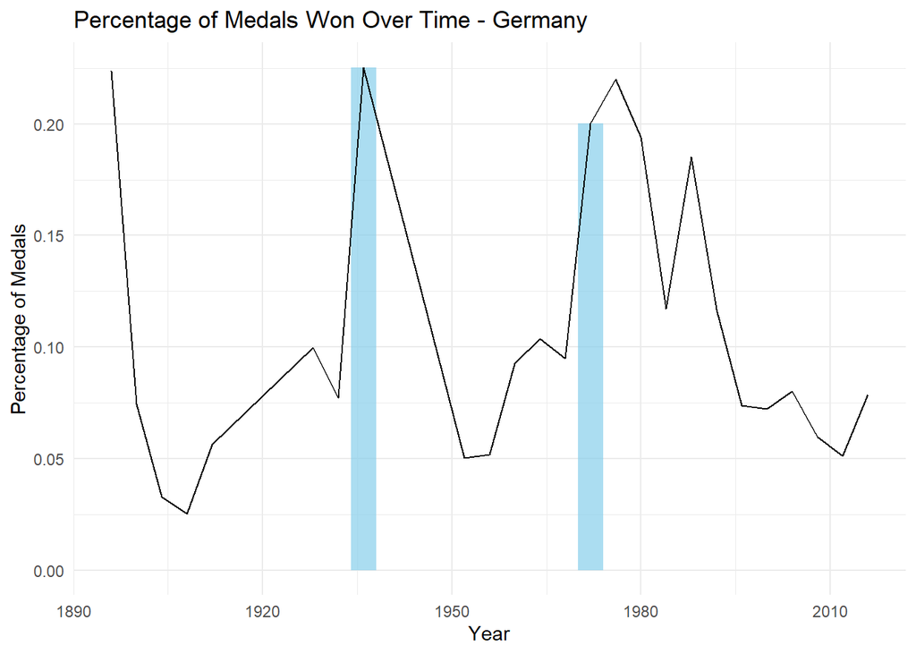

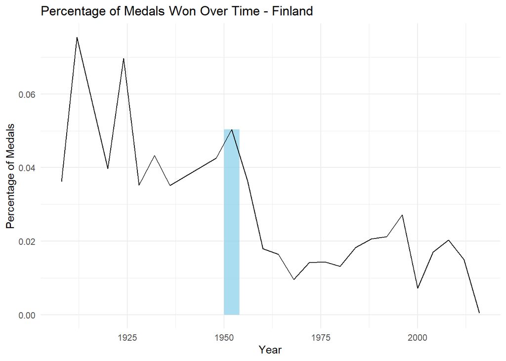

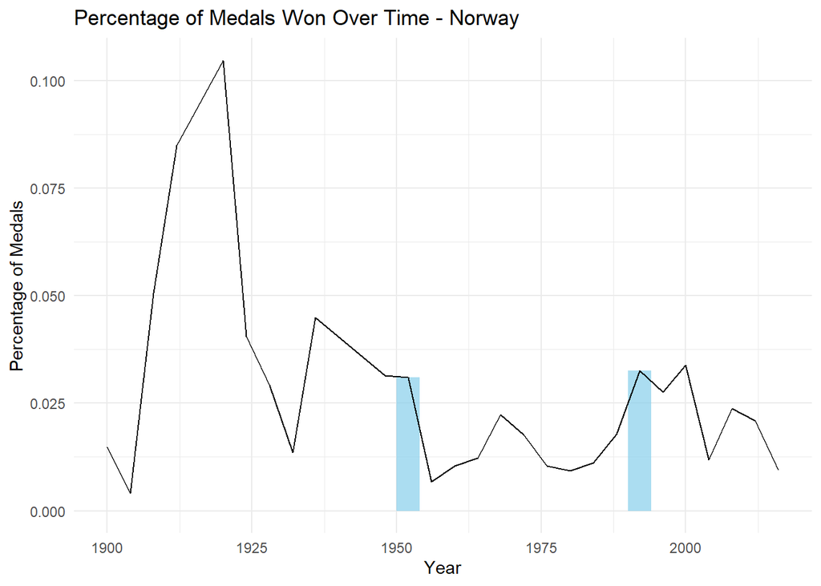

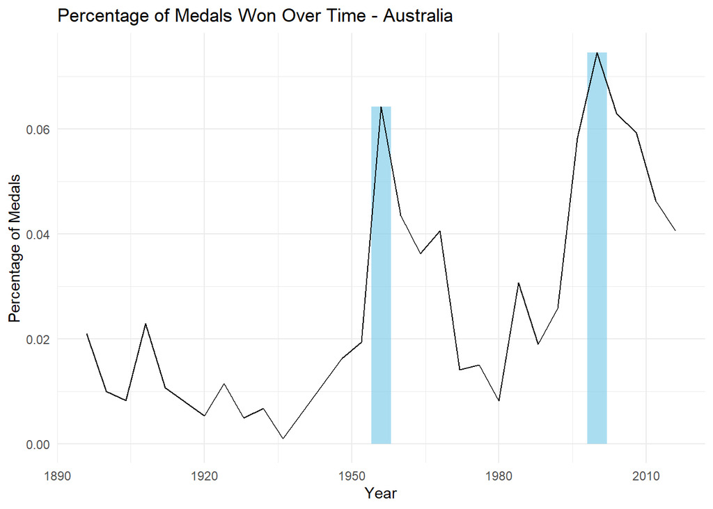

[11 more figures not shown]

```r
# Get the list of countries that have hosted
host_countries_lst <- unique(clean_data$Country)

# Loop through the list of host countries
for (country in host_countries_lst) {

  # Filter data for the current country
  medals_per_country <- clean_data %>%
    group_by(AdjustedYear, AthleteCountry) %>%
    summarise(Medals = sum(!is.na(Medal)), .groups = 'drop')

  hosting_years <- clean_data %>%
    filter(HomeAway == 'Home' & Country == country & Season == 'Summer') %>%
    pull(AdjustedYear) %>%
    unique()

  plot_data <- clean_data %>%
    group_by(AdjustedYear) %>%
    summarize(TotalMedals = sum(!is.na(Medal)), .groups = 'drop') %>%
    left_join(medals_per_country, by = 'AdjustedYear') %>%
    mutate(MedalsPercent = Medals / TotalMedals) %>%
    filter(AthleteCountry == country)

  country_medals <- plot_data %>% filter(AdjustedYear %in% hosting_years)

  # Create the plot
  p <- ggplot(data = plot_data, aes(x = AdjustedYear)) +
    geom_bar(data = country_medals, aes(y = MedalsPercent), stat = "identity", width = 4, fill = "skyblue", alpha = 0.7) +
    geom_line(aes(y = MedalsPercent)) +
    labs(title = paste("Percentage of Medals Won Over Time -", country),
         x = "Year",
         y = "Percentage of Medals") +
    theme_minimal()

  # Print the plot for the current country
  print(p)
}
```

# Correlation of medals to GDP or Population